# Make Policy Predictions using Machine Learning

1. Set the working directory
2. Load policies from the CSV file
3. Set the seed to 123 to make randomness reproducable

### Problem 1: Prepare the Data

4. Create a dataset called “full” containing just Gender, State, Age, and Rate
5. Inspect the first six rows

```
##   Gender State Age     Rate
## 1   Male    MA  77 0.033200
## 2   Male    VA  82 0.067000
## 3   Male    NY  31 0.001000
## 4   Male    TN  39 0.001900
## 5   Male    FL  68 0.014975
## 6   Male    WA  64 0.013150
```

6. Eliminate rows containing NA values
7. Find the average rate

```
## [1] 0.01179769
```

8. Create a categorical variable called “Risk” with two classes (i.e. High and Low)  
   *NOTE: Use “Low” if less than or equal to average Rate and “High” if greater than average Rate*
9. Convert Risk to a factor variable
10. Remove the Rate column  
    *Hint: Set the column equal to NULL*
11. Inspect the first six rows

```
##   Gender State Age Risk
## 1   Male    MA  77 High
## 2   Male    VA  82 High
## 3   Male    NY  31  Low
## 4   Male    TN  39  Low
## 5   Male    FL  68 High
## 6   Male    WA  64 High
```

12. Randomly sample 1500 out of the 2000 row indexes
13. Create a training set called “train” from the indexes
14. Create a test set called “test” from the remaining indexes

### Problem 2: Predict using a Decision Tree

15. Load the tree package
16. Train the decision tree model with “Risk ~ Gender + Age”  
    *NOTE: We can’t use State because tree only suports 32 levels in predictor variables*
17. Inspect the model

```
##
## Classification tree:
## tree(formula = Risk ~ Gender + Age, data = train)
## Number of terminal nodes:  7
## Residual mean deviance:  0.1254 = 187.3 / 1493
## Misclassification error rate: 0.03067 = 46 / 1500
```

18. Plot the model

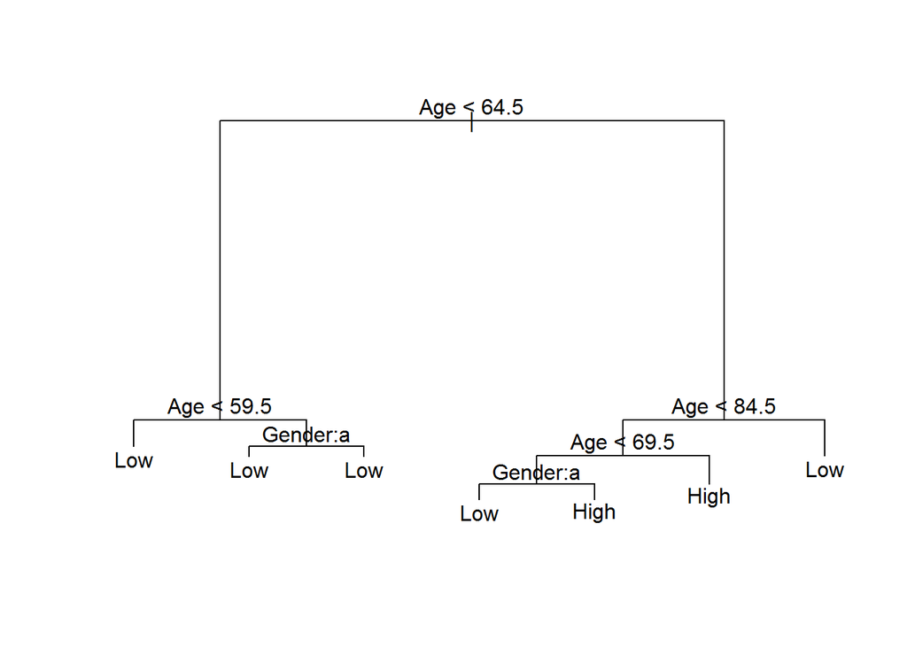

Question: How do you interpret this model?

19. Predict the test data set with the model
20. Summarize the prediction accuracy

```
##       y
## x      High Low
##   High  124   1
##   Low    15 360
```

21. Load the caret package
22. Evaluate the prediction results

```
## Confusion Matrix and Statistics
##
##           Reference
## Prediction High Low
##       High  124   1
##       Low    15 360
##
##                Accuracy : 0.968
##                  95% CI : (0.9486, 0.9816)
##     No Information Rate : 0.722
##     P-Value [Acc > NIR] : < 2.2e-16
##
##                   Kappa : 0.9177
##  Mcnemar's Test P-Value : 0.001154
##
##             Sensitivity : 0.8921
##             Specificity : 0.9972
##          Pos Pred Value : 0.9920
##          Neg Pred Value : 0.9600
##              Prevalence : 0.2780
##          Detection Rate : 0.2480
##    Detection Prevalence : 0.2500
##       Balanced Accuracy : 0.9447
##
##        'Positive' Class : High
##
```

23. Note the accuracy

```
## Accuracy
##    0.968
```

### Problem 3: Predict using a Naive Bayes Classifier

24. Load the e1071 package
25. Train the model
26. Inspect the model

```
##         Length Class  Mode
## apriori 2      table  numeric
## tables  3      -none- list
## levels  2      -none- character
## call    4      -none- call
```

27. Predict with the model
28. Evaluate the prediction results

```
## Confusion Matrix and Statistics
##
##           Reference
## Prediction High Low
##       High  129  14
##       Low    10 347
##
##                Accuracy : 0.952
##                  95% CI : (0.9294, 0.969)
##     No Information Rate : 0.722
##     P-Value [Acc > NIR] : <2e-16
##
##                   Kappa : 0.8815
##  Mcnemar's Test P-Value : 0.5403
##
##             Sensitivity : 0.9281
##             Specificity : 0.9612
##          Pos Pred Value : 0.9021
##          Neg Pred Value : 0.9720
##              Prevalence : 0.2780
##          Detection Rate : 0.2580
##    Detection Prevalence : 0.2860
##       Balanced Accuracy : 0.9446
##
##        'Positive' Class : High
##
```

29. Note the accuracy

```
## Accuracy
##    0.952
```

### Problem 4: Predict with a Neural Network

30. Load the nnet package
31. Train the model with size = 3, decay = 0.0001, and maxit = 500
32. Inspect the model

[output not shown]

33. Predict with the model
34. Evaluate the prediction results

```
## Confusion Matrix and Statistics
##
##           Reference
## Prediction High Low
##       High  138  11
##       Low     1 350
##
##                Accuracy : 0.976
##                  95% CI : (0.9585, 0.9875)
##     No Information Rate : 0.722
##     P-Value [Acc > NIR] : < 2.2e-16
##
##                   Kappa : 0.9415
##  Mcnemar's Test P-Value : 0.009375
##
##             Sensitivity : 0.9928
##             Specificity : 0.9695
##          Pos Pred Value : 0.9262
##          Neg Pred Value : 0.9972
##              Prevalence : 0.2780
##          Detection Rate : 0.2760
##    Detection Prevalence : 0.2980
##       Balanced Accuracy : 0.9812
##
##        'Positive' Class : High
##
```

35. Note the accuracy

```
## Accuracy
##    0.976
```

Question: Which algorithm provides the highest accuracy?

Question: Which algorithm provides the most transparency?